# Multivariate Statistics and Methodology using R

Exploratory Factor Analysis

Aja Murray, Aja.Murray@ed.ac.uk

# Exploratory factor analysis (EFA)

- EFA used for developing a model of the number and nature of dimensions that describe a psychological construct and their inter-relations
- Procedurally similar to PCA but differs in important ways
  - Uses only the common variance in its calculation
  - Can give quite different results to PCA under some circumstances
  - The resulting dimensions are called **factors**
  - EFA based on a **latent variable model**

# Latent variable models

- Divides the world into **observed variables** and **latent variables** (factors)
  - Observed variables can be measured directly
    - e.g., scores on IQ subtests
  - Latent variables inferred based on patterns of observed variable associations
    - e.g., Spearman’s *g*
- Latent variables generate the correlations between observed variables
  - e.g., higher *g* causes higher subtest scores
- Observed variables are imperfect **indicators** (measures) of latent variables
  - Observed variable scores have both a systematic and a random error component

# Latent variable models as an SEM diagram

[figure not shown]

- Latent variables are ellipses
- Observed variables are rectangles
- Single-headed arrows go from the latent variables to the observed variables
- There are also unique variances for the observed variables

# Doing EFA

- Like PCA, there are a number of decisions:
  - How many factors?
  - Which rotation?
  - **Which extraction method?**
- In EFA we also have to choose an extraction/estimation method

# How many factors?

- As in PCA, we can use the following tools to help us decide how many factors to retain:
  - Scree test
  - Parallel analysis
  - MAP test
- It is also important to examine the factor solutions for varying numbers of factors
  - Which solutions make more sense based on our background knowledge of the construct?
  - Do some solutions have deficiencies such as minor factors?

# Our running example

- Let’s return to our aggression example and now run an EFA
- We had n=1000 participants with data on the following 10 items:
  1. I hit someone
  2. I kicked someone
  3. I shoved someone
  4. I battered someone
  5. I physically hurt someone on purpose
  6. I deliberately insulted someone
  7. I swore at someone
  8. I threatened to hurt someone
  9. I called someone a nasty name to their face
  10. I shouted mean things at someone

# How many aggression factors? Scree test

- We can plot the eigenvalues and look for a kink in the plot:

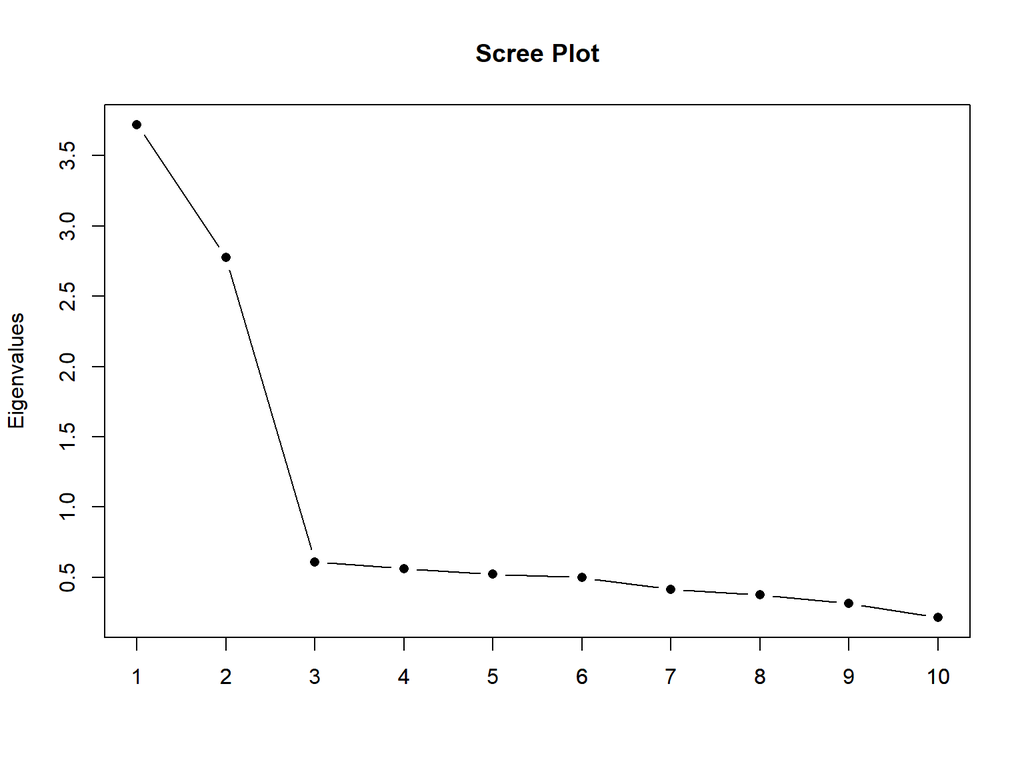

```r
eigenvalues<-eigen(cor(agg.items))$values
plot(eigenvalues, type = 'b', pch = 16,
     main = "Scree Plot", xlab="", ylab="Eigenvalues")
axis(1, at = 1:10, labels = 1:10)
```

# How many aggresion factors? Parallel analysis

- We can conduct a parallel analysis using fa.parallel( )from the psych package:

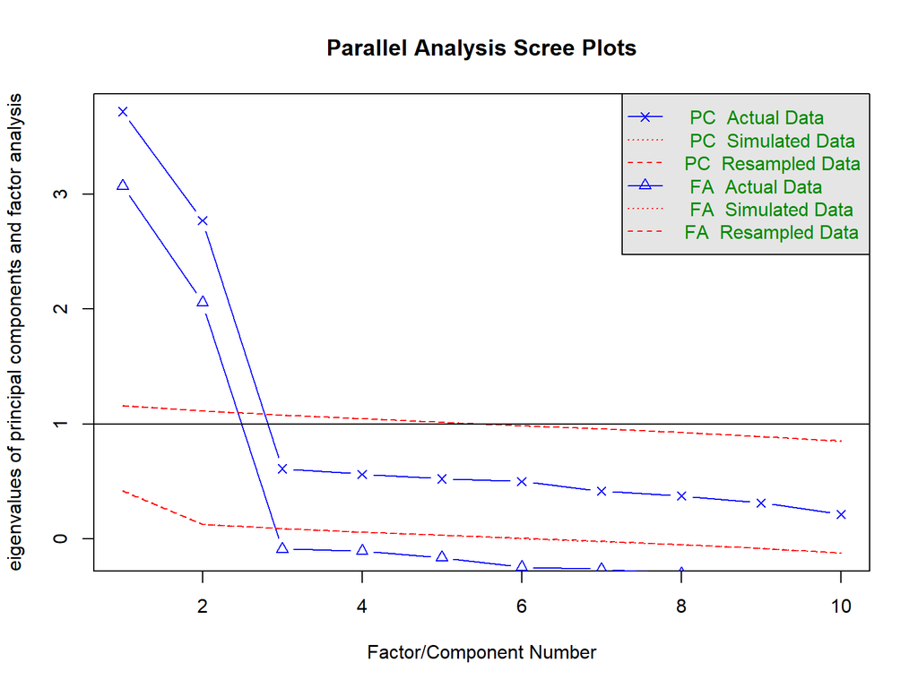

```
## Parallel analysis suggests that the number of factors =  2  and the number of components =  2
```

```r
library(psych)
fa.parallel(agg.items, n.iter=500)
```

# How many aggression factors? MAP

- We can conduct a MAP test using vss( ):

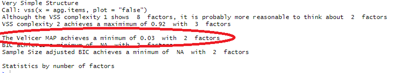

```r
library(psych)
vss(agg.items, plot='false')
```

# Examining the factor solutions

- Finally, we draw on information from the factor solutions themselves
- We run a series of factor analysis models with different numbers of factors
- Look at the loadings and factor correlations:
  - Are important distinctions blurred when the number of factors is smaller?
  - Are there minor or ‘methodological’ factors when the number of factors is larger?
  - Are the factor correlations very high?
  - Do the factor solutions make theoretical sense?
- In this case, given the MAP, scree and parallel analysis results we would likely want to examine the 1,2, and 3 factor solutions

# Conducting EFA in R

- We can run our factor analyses using the fa() function
- The first argument is the dataset with the items we want to factor analyse
- We also need to mention the number of factors we want to extract, e.g., nfactors=1

```r
onef<-fa(agg.items, nfactors=1) #EFA with 1 factor
```

# The one-factor solution

- To help us choose an optimal number of factors, we can look at the one-factor solution…

```r
onef<-fa(agg.items, nfactors=1) #EFA with 1 factor
onef$loadings #inspect the factor loadings
```

```
##
## Loadings:
##        MR1
## item1  0.434
## item2  0.458
## item3  0.409
## item4  0.448
## item5  0.447
## item6  0.534
## item7  0.749
## item8  0.724
## item9  0.608
## item10 0.607
##
##                  MR1
## SS loadings    3.074
## Proportion Var 0.307
```

# The two-factor solution

- And compare with the two-factor solution…

```r
library(psych)
twof<-fa(agg.items, nfactors=2, rotate='oblimin') #EFA with 2 factors
twof$loadings ##inspect the factor loadings
```

```
##
## Loadings:
##        MR1    MR2
## item1          0.689
## item2          0.795
## item3          0.688
## item4          0.646
## item5          0.861
## item6   0.639
## item7   0.865
## item8   0.901
## item9   0.672
## item10  0.715
##
##                  MR1   MR2
## SS loadings    2.938 2.743
## Proportion Var 0.294 0.274
## Cumulative Var 0.294 0.568
```

# The two-factor solution factor correlations

```r
twof$Phi  ## inspect the factor correlations
```

```
##           MR1       MR2
## MR1 1.0000000 0.1535139
## MR2 0.1535139 1.0000000
```

# The three-factor solution

- And the three-factor solution

```r
library(psych)
threef<-fa(agg.items, nfactors=3, rotate='oblimin') #EFA with 3 factors
threef$loadings #inspect the factor loadings
```

```
##
## Loadings:
##        MR1    MR2    MR3
## item1          0.689
## item2          0.807
## item3          0.619  0.305
## item4          0.655
## item5          0.867
## item6   0.638        -0.106
## item7   0.864
## item8   0.898
## item9   0.671
## item10  0.723         0.120
##
##                  MR1   MR2   MR3
## SS loadings    2.941 2.698 0.126
## Proportion Var 0.294 0.270 0.013
## Cumulative Var 0.294 0.564 0.576
```

# The three-factor solution factor correlations

```r
threef$Phi # inpsect the factor correlations
```

```
##            MR1       MR2        MR3
## MR1 1.00000000 0.1486395 0.02470414
## MR2 0.14863950 1.0000000 0.26161577
## MR3 0.02470414 0.2616158 1.00000000
```

# BREAK 1

- Time for a pause!
- Quiz question:
  - In an SEM diagram how are latent variables represented?
    - 1. rectangles
    - 2. triangles
    - 3. diamonds
    - 4. ellipses

# Welcome back 1

- Welcome back!
- The answer to the quiz question is…
  - In an SEM diagram how are latent variables represented?
    - 1. rectangles
    - 2. triangles
    - 3. diamonds
    - 4. **ellipses**

# reminder: SEM diagram

[figure not shown]

# Factor extraction in EFA

- **Factor extraction** refers to the method of deriving the factors
- PCA is itself an extraction method
- In EFA there are a number of factor extraction options:
  - principal axis factoring (PAF)
  - ordinary least squares (OLS)
  - weighted least squares (WLS)
  - minres
  - maximum likelihood (ML)

# Principal axis factoring (PAF)

- Traditional method
- An eigendecomposition of a reduced form of correlation matrix
  - Diagonals are replaced by communalities
  - Communalities estimates used as starting point
    - Estimates of the variance shared with other indicators
    - Based on e.g. multiple squared R
  - Iteratively updated across successive PAFs
  - Process terminates when estimates change little across iterations
- Focus on *common* rather than all variance is key EFA vs PCA distinction

# Other extraction methods

- **OLS** finds the factor solution that minimises difference between observed and model-implied covariance matrices
  - specifically, minimises the sum of squared residuals
- **WLS** up-weights the variables with higher communalities
- **minres** ignores the diagonals
- **ML** finds the factor solution that maximises the likelihood of the observed covariance matrix

# Which to use?

- PAF is a good option
- minres can provide EFA solutions when other methods fail
  - minres is the default for the fa( ) function
- choice of extraction method usually makes little difference if:
  - communalities are similar
  - sample size is large
  - the number of variables is large

# PAF

- We can do a factor analysis with PAF by setting fm=‘pa’ in the fa() function:

```r
library(psych)
twof<-fa(agg.items, nfactors=2, rotate='oblimin', fm='pa') #EFA with 2 factors
twof$loadings ##inspect the factor loadings
```

```
##
## Loadings:
##        PA1    PA2
## item1          0.689
## item2          0.795
## item3          0.688
## item4          0.646
## item5          0.860
## item6   0.639
## item7   0.865
## item8   0.900
## item9   0.672
## item10  0.716
##
##                  PA1   PA2
## SS loadings    2.937 2.742
## Proportion Var 0.294 0.274
## Cumulative Var 0.294 0.568
```

```r
twof$Phi  ## inspect the factor correlations
```

```
##          PA1      PA2
## PA1 1.000000 0.153633
## PA2 0.153633 1.000000
```

# minres

- minres is the default method but we can also explicitly set fm=‘minres’:

```r
library(psych)
twof<-fa(agg.items, nfactors=2, rotate='oblimin', fm='minres') #EFA with 2 factors
twof$loadings ##inspect the factor loadings
```

```
##
## Loadings:
##        MR1    MR2
## item1          0.689
## item2          0.795
## item3          0.688
## item4          0.646
## item5          0.861
## item6   0.639
## item7   0.865
## item8   0.901
## item9   0.672
## item10  0.715
##
##                  MR1   MR2
## SS loadings    2.938 2.743
## Proportion Var 0.294 0.274
## Cumulative Var 0.294 0.568
```

```r
twof$Phi  ## inspect the factor correlations
```

```
##           MR1       MR2
## MR1 1.0000000 0.1535139
## MR2 0.1535139 1.0000000
```

# Factor rotation

- Like in PCA:
  - Rotation needed to make solution interpretable
  - Main choice is between oblique vs orthogonal
  - Oblique often preferable as allows correlated or uncorrelated factors
  - Orthogonal rotation yields one loading matrix
  - Oblique yields both pattern and structure loading matrices
    - Pattern matrix is usually used as basis for interpretation

# Interpreting the factor solution

- Label factors on basis of high loading items

```r
library(psych)
twof<-fa(agg.items, nfactors=2, rotate='oblimin', fm='minres') #EFA with 2 factors
twof$loadings ##inspect the factor loadings
```

```
##
## Loadings:
##        MR1    MR2
## item1          0.689
## item2          0.795
## item3          0.688
## item4          0.646
## item5          0.861
## item6   0.639
## item7   0.865
## item8   0.901
## item9   0.672
## item10  0.715
##
##                  MR1   MR2
## SS loadings    2.938 2.743
## Proportion Var 0.294 0.274
## Cumulative Var 0.294 0.568
```

# Interpreting the factor solution

- Factor 1 could be labelled *verbal aggression* and factor 2 could be labelled *physical aggression*
  1. **I hit someone**
  2. **I kicked someone**
  3. **I shoved someone**
  4. **I battered someone**
  5. **I physically hurt someone on purpose**
  6. I deliberately insulted someone
  7. I swore at someone
  8. I threatened to hurt someone
  9. I called someone a nasty name to their face
  10. I shouted mean things at someone

# The magnitude of factor loadings

- How large are the loadings?
- Comfrey & Lee (1992) offered the following rules of thumb:
  - > .71 (50% overlapping variance) are considered excellent
  - > .63 (40% overlapping variance) is very good
  - > .55 (30% overlapping variance) is good
  - > .45 (20% overlapping variance) is fair
  - > .32 (10% overlapping variance) is poor

# The magnitude of factor correlations

- How distinct are the factors?

```r
library(psych)
twof<-fa(agg.items, nfactors=2, rotate='oblimin', fm='minres') #EFA with 2 factors
twof$Phi  ## inspect the factor correlations
```

```
##           MR1       MR2
## MR1 1.0000000 0.1535139
## MR2 0.1535139 1.0000000
```

# How much variance is accounted for by the factors?

- We can also check how much variance overall is accounted for by the factors

```r
twof
```

```
## Factor Analysis using method =  minres
## Call: fa(r = agg.items, nfactors = 2, rotate = "oblimin", fm = "minres")
## Standardized loadings (pattern matrix) based upon correlation matrix
##          MR1   MR2   h2   u2 com
## item1   0.03  0.69 0.48 0.52   1
## item2   0.00  0.79 0.63 0.37   1
## item3   0.00  0.69 0.47 0.53   1
## item4   0.07  0.65 0.44 0.56   1
## item5  -0.04  0.86 0.73 0.27   1
## item6   0.64 -0.03 0.40 0.60   1
## item7   0.86  0.03 0.76 0.24   1
## item8   0.90 -0.03 0.80 0.20   1
## item9   0.67  0.04 0.46 0.54   1
## item10  0.72 -0.01 0.51 0.49   1
##
##                        MR1  MR2
## SS loadings           2.94 2.75
## Proportion Var        0.29 0.27
## Cumulative Var        0.29 0.57
## Proportion Explained  0.52 0.48
## Cumulative Proportion 0.52 1.00
##
##  With factor correlations of
##      MR1  MR2
## MR1 1.00 0.15
## MR2 0.15 1.00
##
## Mean item complexity =  1
## Test of the hypothesis that 2 factors are sufficient.
##
## The degrees of freedom for the null model are  45  and the objective function was  4.66 with Chi Square of  4638.35
## The degrees of freedom for the model are 26  and the objective function was  0.03
##
## The root mean square of the residuals (RMSR) is  0.01
## The df corrected root mean square of the residuals is  0.02
##
## The harmonic number of observations is  1000 with the empirical chi square  11.97  with prob <  0.99
## The total number of observations was  1000  with Likelihood Chi Square =  27.13  with prob <  0.4
##
## Tucker Lewis Index of factoring reliability =  1
## RMSEA index =  0.007  and the 90 % confidence intervals are  0 0.026
## BIC =  -152.47
## Fit based upon off diagonal values = 1
## Measures of factor score adequacy
##                                                    MR1  MR2
## Correlation of (regression) scores with factors   0.95 0.94
## Multiple R square of scores with factors          0.91 0.88
## Minimum correlation of possible factor scores     0.82 0.75
```

# BREAK 2

- Time for a pause
- Quiz question:
  - Which of these best describe principal axis factoring extraction?
    - A PCA of a correlation matrix with communalities on the diagonals?
    - A PCA of a correlation matrix ignoring the diagonals?
    - A PCA of a correlation matrix where the the off-diagonals are replaced with communalities?
    - A PCA of a correlation matrix where all elements are replaced by communalities?

# Welcome back 2

- Welcome back!
- The answer to the quiz question is…
  - Which of these best describe principal axis factoring extraction?
    - **A PCA of a correlation matrix with communalities on the diagonals?**
    - A PCA of a correlation matrix ignoring the diagonals?
    - A PCA of a correlation matrix where the the off-diagonals are replaced with communalities?
    - A PCA of a correlation matrix where all elements are replaced by communalities?

# Checking the suitability of data for EFA

- The first step in an EFA is actually to check the appropriateness of the data:
  - Does the data look multivariate normal?
  - Do the relations look linear?
  - Does the correlation matrix have good factorability?

# Multivariate normality

- Do the variables have (approximately) continuous measurement scales?
  - 5 or more response options
- Examining univariate distributions using histograms

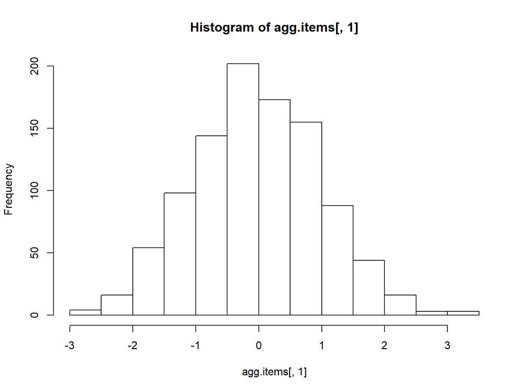

```r
hist(agg.items[ ,1])
```

# Linearity

- Plot linear and lowess lines for pairwise relations and compare

```r
library(car)
```

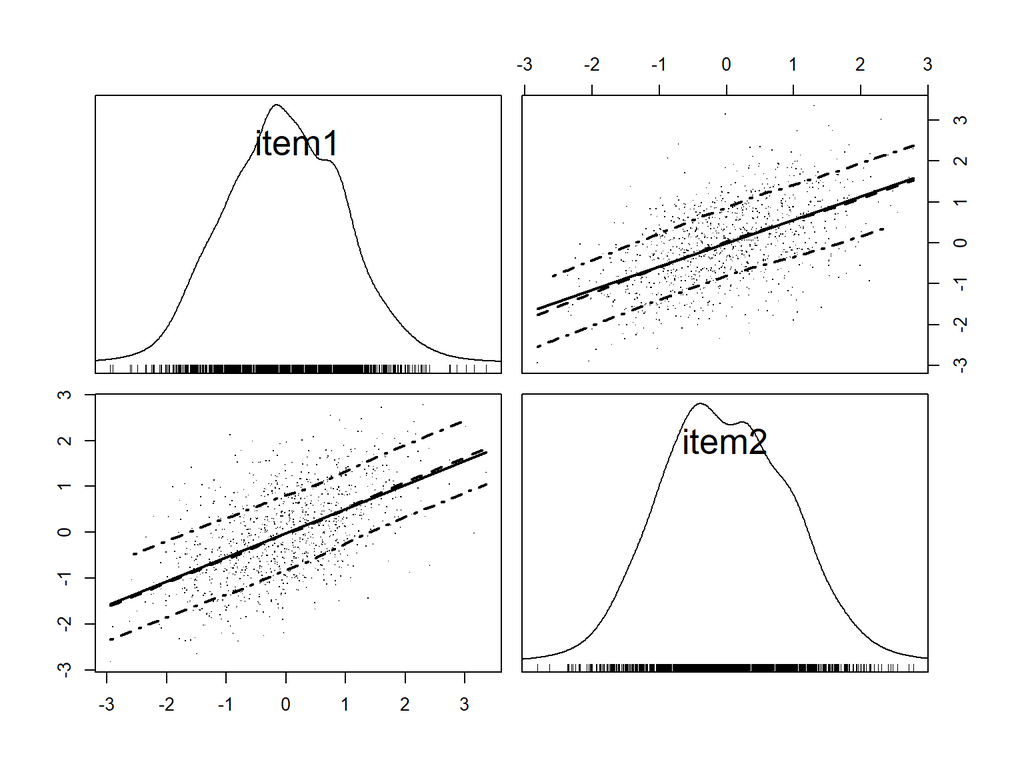

```r
scatterplotMatrix(agg.items[ ,1:2], pch='.', col='black', plot.points=T, diagonal='histogram')
```

# Factorability

- EFA focuses on variance **common** to items
  - Not much point in an EFA if little variance in common
- Use Kaiser-Meyer-Olkin (KMO) test
  - Provides measure of proportion of variance shared between variables
  - Can be computed for individual variables or whole correlation matrix
  - Overall values >.60 and no variable <.50 is ideal

# KMO in R

```r
KMO(agg.items)
```

```
## Kaiser-Meyer-Olkin factor adequacy
## Call: KMO(r = agg.items)
## Overall MSA =  0.86
## MSA for each item =
##  item1  item2  item3  item4  item5  item6  item7  item8  item9 item10
##   0.89   0.85   0.89   0.90   0.82   0.92   0.83   0.81   0.92   0.90
```

# Reporting EFA

- Transparency and reproducibility
- Methods
  - Methods to determine number of factors
  - Extraction method
  - Rotation method
- Results
  - Information about data suitability for EFA
  - Number of factors (and why)
  - Loading matrix
  - Factor correlations
  - Interpretation of factors (and why)
  - Variance explained by factors

# Summary

- Steps in EFA are similar to PCA but…
  - The underlying theory and interpretation is quite different
  - Their results can differ if there is not a lot of common variance
- EFA involves:
  - Checking data suitability
  - Choosing number of factors
  - Factor extraction
  - Rotation
  - Interpretation of factors